# Pre-processing ASVs with Phyloseq

Hilal Samut

2025-03-30

# Goals

First, we will use the [phyloseq package](https://joey711.github.io/phyloseq/) to combine all of our data objects that we exported from the DADA2 workflow (`asv_table`, `tax_table`, and metadata) and incorporate them into a single [specialized S4 R Data object](https://adv-r.hadley.nz/s4.html), known as a phyloseq object. Then, we will remove any potential contaminants and evaluate the accuracy of our sequencing run. Finally, we will write our single `raw_preprocessed_physeq` phyloseq data object.

## Specific Steps:

1. Load in data that we’ve generated in `analysis/02_AssignASVs.Rmd` and fix all of the names to match each other. *The names must match for us to incorporate them into the S4 phyloseq object*:
   1. `asv_table`: ASVs (rows) x Samples (columns)
   2. `tax_table`: ASV (rows) x Taxonomy (columns)
   3. `metadata`: Samples (rows) x All our data (*e.g. pH, Temp, treatment group, etc*; columns)
2. Combine the data into a phyloseq object.
3. Remove any contaminating ASVs that are **chloroplasts**.
4. Remove ASVs that are **mitochondria**.
5. Evaluate any ASVs from the **negative controls**. Then, remove negative controls.
6. Evaluate the mock community or **positive control** to learn the accuracy of sequencing.
7. Check for **reverse complements**.
8. Check the **sequencing depth** of samples. Remove samples that obviously have too few reads.
9. Write a `raw_preprocessed_physeq` to be used in the next step of our workflow.

## Output

1. A **pre-processed S4 phyloseq object**: `raw_preprocessed_physeq.RData`.

### Wait, what’s metadata?

**Metadata** in 16S rRNA sequencing projects refers to the descriptive information about each sample, such as sample ID, collection site, date, treatment group, environmental conditions (*e.g.,* pH, temperature), or host characteristics. This is the data that we need to have organized so we can connect the community parameters that we are measuring to the actual scientific question we are asking.

So, for this dataset, we are wondering how the microbial biodiversity (*i.e.,* alpha or within-sample diversity) and community composition (*i.e.,* beta or between-sample diversity) influence the survival of Listeria monocytogenes and E. coli O157:H7 at the end of shelf life and five days post-shelf life of chopped Romaine lettuce. Therefore, we need to have information about the treatment groups and storage durations of each sample! The metadata file is where we will access this information.

In a **phyloseq object**, metadata is stored as a `sample_data()` table and is essential for grouping, comparing, and visualizing microbial communities across different experimental or environmental conditions. Wait, *what’s a phyloseq object*?!

### What is a phyloseq object?

Below is figure 3 from the phyloseq paper by [McMurdie et al. (2013) in PLoS ONE](http://journals.plos.org/plosone/article?id=10.1371/journal.pone.0061217).

Phyloseq

[figure not shown]

#### Why use phyloseq?

It’s about making our job as microbial ecologists easier! Phyloseq helps us as researchers to:

- Efficiently integrates multiple data types in (microbiome/sequencing) research.
- Supports biodiversity analyses (alpha, beta diversity) and statistical tests, which we are working towards.
- Access built-in functions for filtering (`prune_taxa()`, `prune_samples()`), subsetting (`subset_taxa()`, `subset_samples()`), and normalizing data across a database.
- Enables easy visualization with functions like `plot_richness()`, `ordinate()`, and `plot_ordination()`.

# Set Environment

## Load Packages

```r
#install.packages("BiocManager")
#BiocManager::install("Biostrings")

# NOTE, you will need to install the following 2 packages to
# re-create the negative control plots below!
#install.packages("ggpubr")
#install.packages("rstatix")

# Load packages with pacman
# Be sure that you load dada2 & Patchwork, which we didn't do in class on March 12th
pacman::p_load(devtools, phyloseq, dada2, patchwork, Biostrings, tidyverse,
               # Note to add ggpubr & rstatix!!
               ggpubr, rstatix, install = FALSE)
```

## Timing of this script

Let’s record how long this file took to run on the class server, which we will record at the end of the script.

```r
# What time did we start running this script?
start_time <- Sys.time()
```

## 1. Load Data

### 1a. Metadata

Here, we will load in our **metadata** files, which include:

1. `data/metadata.csv`: This file contains all of our samples and also any measured variables, including station, date of collection, depth of sample, temperature, pH, salinity, etc.
2. `data/01_DADA2/track_read_counts.RData`: This file contains how many reads we maintained in our samples through the DADA2 workflow.

**Where’s your metadata?**

If you **downloaded a dataset from the NCBI/ENA**, then you’ve likely have data that matches with your fastq files that you’ve downloaded via the SRA “Run Selector”. You will need to have the data that matches your scientific question–remember, we are doing science!? (*It’s so easy to get lost in all the nitty gritty of our bioinformatics project.*)

If you have **data from your own research or from you lab’s research**, hopefully you have access to a curated, quality controlled, and cleaned up table where you can match the current name of your samples to their sample information (*e.g.,* disease state, host type, experimental group, environmental parameters, etc). This table will include the column(s) that will match with your scientific question.

```r
# load in metadata
metadata_df <-
  read_csv("data/metadata.csv") %>%
  # Fix Column Name
  dplyr::rename("sample_names" = "Run") %>%
  # Add sample names also as a column
  mutate(names = sample_names)
# Inspect
head(metadata_df)
```

```
## # A tibble: 6 × 48
##   sample_names `Assay Type` AvgSpotLen     Bases batch BioProject  BioSample
##   <chr>        <chr>             <dbl>     <dbl> <chr> <chr>       <chr>
## 1 SRR17327669  AMPLICON            602 186568830 B3    PRJNA792031 SAMN24372341
## 2 SRR17327670  AMPLICON            602 182038780 B3    PRJNA792031 SAMN24372340
## 3 SRR17327671  AMPLICON            602 212356704 B3    PRJNA792031 SAMN24372339
## 4 SRR17327672  AMPLICON            602 186818058 B3    PRJNA792031 SAMN24372338
## 5 SRR17327673  AMPLICON            602 186827088 B3    PRJNA792031 SAMN24372337
## 6 SRR17327678  AMPLICON            602 177037966 B3    PRJNA792031 SAMN24372332
## # ℹ 41 more variables: BioSampleModel <chr>, brand <chr>, Bytes <dbl>,
## #   `Center Name` <chr>, Collection_Date <chr>, Consent <chr>,
## #   `DATASTORE filetype` <chr>, `DATASTORE provider` <chr>,
## #   `DATASTORE region` <chr>, env_broad_scale <chr>, env_local_scale <chr>,
## #   env_medium <chr>, Experiment <chr>, geo_loc_name_country <chr>,
## #   geo_loc_name_country_continent <chr>, geo_loc_name <chr>, Group <chr>,
## #   HOST <chr>, Inoculum <chr>, Instrument <chr>, isolation_source <chr>, …
```

```r
dim(metadata_df)
```

```
## [1] 108  48
```

```r
# include dada2 output
load("data/01_DADA2/track_read_counts.RData")

# Take a look
glimpse(track_counts_df)
```

```
## Rows: 108
## Columns: 6
## $ sample_names <chr> "SRR17327669_R1_filtered.fastq.gz", "SRR17327670_R1_filte…
## $ denoisedF    <dbl> 236818, 235028, 274451, 243401, 242325, 292421, 244539, 2…
## $ denoisedR    <dbl> 237135, 235388, 275091, 243518, 242727, 292860, 244686, 2…
## $ merged       <dbl> 80428, 104805, 109210, 179010, 128568, 149039, 209896, 15…
## $ nochim       <dbl> 78950, 103055, 107358, 175430, 126749, 146156, 206423, 15…
## $ num_ASVs     <dbl> 59, 71, 62, 44, 64, 76, 47, 28, 37, 47, 49, 34, 48, 34, 6…
```

```r
dim(track_counts_df)
```

```
## [1] 108   6
```

```r
# Check filenames
head(track_counts_df$sample_names)
```

```
## [1] "SRR17327669_R1_filtered.fastq.gz" "SRR17327670_R1_filtered.fastq.gz"
## [3] "SRR17327671_R1_filtered.fastq.gz" "SRR17327672_R1_filtered.fastq.gz"
## [5] "SRR17327673_R1_filtered.fastq.gz" "SRR17327674_R1_filtered.fastq.gz"
```

```r
# Fix sample names in track_reads
track_counts_df$sample_names <- sapply(strsplit(track_counts_df$sample_names, "_"), `[`, 1)

# Intuition check
head(track_counts_df$sample_names)
```

```
## [1] "SRR17327669" "SRR17327670" "SRR17327671" "SRR17327672" "SRR17327673"
## [6] "SRR17327674"
```

```r
# What's different?
setdiff(track_counts_df$sample_names, metadata_df$sample_names)
```

```
## character(0)
```

```r
# Let's do a filtering join with left_join
metadata_final_df <-
  metadata_df %>%
  left_join(., track_counts_df, by = "sample_names") %>%
  # sample names to the rownames to merge into phyloseq
  column_to_rownames(var = "sample_names")

# Check
dim(metadata_final_df)
```

```
## [1] 108  52
```

### 1b. ASV Table

Now, let’s load in the ASV count table that we created within DADA2 in `analysis/02_AssignASVs.Rmd`.

```r
asv_df <-
  read.delim(file = "data/01_DADA2/ASV_table.tsv", sep = "\t",
           # add the column names and row names
           header = TRUE, row.names = 1)

# Inspect
asv_df[1:3, 1:3]
```

```
##          SRR17327669 SRR17327670 SRR17327671
## ASV_0001       71968       94380       97697
## ASV_0002        3021        3819        4978
## ASV_0003         455         696         636
```

```r
# fix Column names
## Remove the X: denote at the beginning "^"
#colnames(asv_df) <- sub(pattern = "^X", replacement = "" , colnames(asv_df))
## Replace the . with a -: "\\." since . is a special character in regex
#colnames(asv_df) <- gsub(pattern = "\\.", replacement = "-", colnames(asv_df))

# Final inspection
head(colnames(asv_df))
```

```
## [1] "SRR17327669" "SRR17327670" "SRR17327671" "SRR17327672" "SRR17327673"
## [6] "SRR17327674"
```

```r
asv_df[1:3, 1:3]
```

```
##          SRR17327669 SRR17327670 SRR17327671
## ASV_0001       71968       94380       97697
## ASV_0002        3021        3819        4978
## ASV_0003         455         696         636
```

### 1c. Taxonomy Table

And, let’s also load the taxonomy table that we created in `analysis/02_AssignASVs.Rmd`.

```r
tax_df <-
  read.delim("data/01_DADA2/ASV_taxonomy.tsv", sep = "\t",
           header = TRUE, row.names = 1)

# Inspect
dim(tax_df)
```

```
## [1] 536   9
```

```r
dim(asv_df)
```

```
## [1] 536 108
```

```r
# Add check
stopifnot(rownames(asv_df) == rownames(tax_df))
```

# 2. Handoff to phyloseq

This is where we will combine our metadata, asv count table, and taxonomy table into a single data S4 data object in R, which we will call `raw_physeq` for now.

```r
raw_physeq <-
  phyloseq(otu_table(asv_df, taxa_are_rows = TRUE),
         sample_data(metadata_final_df),
         tax_table(as.matrix(tax_df)))

# Check out
raw_physeq
```

```
## phyloseq-class experiment-level object
## otu_table()   OTU Table:         [ 536 taxa and 108 samples ]
## sample_data() Sample Data:       [ 108 samples by 52 sample variables ]
## tax_table()   Taxonomy Table:    [ 536 taxa by 9 taxonomic ranks ]
```

```r
# save
save(raw_physeq, file = "data/03_PreProcessing/raw_physeq.RData")
```

# Clean up the data!

**Chloroplasts** and **mitochondria** need to be removed from 16S datasets because they contain their own 16S rRNA genes, which are evolutionarily derived from bacteria. These organelles can be unintentionally amplified during PCR, especially in samples from plants (chloroplasts) or animals (mitochondria), leading to misleading results by inflating microbial diversity.

This is explained by the endosymbiotic theory, which proposes that mitochondria and chloroplasts originated from free-living bacteria that were engulfed by ancestral eukaryotic cells. Over time, they became permanent, symbiotic organelles with their own genomes. Because of this bacterial ancestry, their 16S rRNA genes are similar to those targeted in bacterial 16S profiling, even though they are part of the host organism and not part of the microbial community being studied.

Removing these sequences ensures the analysis reflects true bacterial and archaeal diversity in the environment or host.

## 3. Remove chloroplasts

```r
noChloros_physeq <-
  raw_physeq %>%
  subset_taxa(Order != "Chloroplast" | is.na(Order))

# How many ASVs were chloroplasts?
numChloros_ASVs <- ntaxa(raw_physeq) - ntaxa(noChloros_physeq)
```

There were 68 ASVs that were chloroplasts.

## 4. Remove Mitochondria

```r
noChlorosMitos_physeq <-
  noChloros_physeq %>%
  subset_taxa(Family != "Mitochondria" | is.na(Family))

# How many ASVs were mitochondria?
numMitos_ASVs <- ntaxa(noChloros_physeq) - ntaxa(noChlorosMitos_physeq)
```

There were 12 ASVs that were mitochondria in the data set.

INTERPRETATION #1: How many chloroplast and/or mitochondrial ASVs in your dataset? Does this seem reasonable?: In my dataset, I had 68 and 12 chloroplast and mitochondrial ASVs. The reason why I have higher number of chloroplast ASVs might be due to the plant cells might have been ruptured, releasing their content. In addition, the chloroplast content of photosynthetic cells is higher compared to mitochondrial content. That’s why I expect to have higher chloroplast ASVs in my dataset.

# Evaluate and remove the control samples

Now, let’s take a look at the negative controls and then make a decision about whether or not to remove the ASVs that we found in our controls

1. Negative controls
2. ASVs found within the negative controls and their distribution in the samples.
3. Evaluate the mock community

## 5. Negative Controls

Including negative controls in your 16S sequencing workflow is a critical step that helps you identify potential contamination and confidently interpret your results—**especially if you’re working with low-biomass** samples like water, air, or host-associated (*e.g.,* skin, etc) surfaces.

Even in the cleanest labs, contamination can creep in at any point in the pipeline: from the DNA extraction kit, PCR reagents, plastic consumables, or even aerosols in the lab. These contaminants often include low-level bacterial DNA that can be amplified just as efficiently as your true sample DNA, leading to false signals in your data. Negative controls help you detect and remove these artifacts.

The main types of negative controls you should consider including in your 16S rRNA gene analyses include the following:

1. **DNA Extraction Blank (Extraction Negative Control):** This control is processed alongside your samples but without any actual biological material—you just use the extraction buffer or nuclease-free water. It goes through the entire DNA extraction process, just like your real samples. Each time you open a new kit another DNA extraction blank should be created! In our lab, we always record the lot number of our extraction kit and add it to the DNA metadata for that sample.
   - *Why it’s important:* This control helps you detect contamination introduced during the extraction step—often from kits (a phenomenon known as the kitome), tubes, pipette tips, or other surfaces.
2. **PCR No-Template Control (NTC):** For this control, you set up a PCR reaction using water instead of DNA as the template. Everything else—primers, polymerase, buffer—is the same as your actual PCR reactions.
   - *Why it’s important:* This checks for contaminants introduced during PCR setup, such as aerosolized DNA, primer dimer artifacts, or contamination from reagents like Taq or water.
   - *Note:* A NTC control should be included in your dataset from each step of PCR that your sample goes through. For example, **in the standard Illumina 2-step PCR library prep, two separate NTC controls should be included** for both the 1st PCR step where the 16S rRNA gene-specific primers are used with the Illumina adapter overhangs, and the 2nd PCR step where the indices and P5 and P7 are added to the end of the amplicons. Therefore, a blank sample that is carried all the way through barcoding, library prep, pooling, and sequencing. Treat it exactly like a real sample in your workflow. These control helps detect contamination introduced within and after PCR, such as cross-contamination during amplicon pooling, barcode cross-talk, or reagent contamination during library preparation.
3. **Field Control:** This type of control is a blank sample (*e.g.,* sterile water, buffer, or a clean swab) that is handled *exactly* like your real samples, but without exposure to the environment or biological material that is being studied. It goes through:
   - The same collection materials (e.g., bottles, filters, swabs).
   - The same handling (e.g., gloves, tools, transport containers).
   - And is stored or processed at the same time and under the same conditions as your actual field samples.
   - Extracted and prepared exactly as every other sample.
   - *What are examples of field controls?*
     - Examples:
       - *Water samples:* Pour sterile water into a sterile sampling bottle at the site (without exposing it to the lake/river), filter it as if it were a sample.
       - *Swab samples:* Open a sterile swab, wave it near the sampling area without touching anything, then store it with your other samples.
       - *Sediment or soil samples*: Open up the collection tube to the open air and use a clean scoop (with the same cleaning method as you would between actual samples) to transfer sterile material or nothing at all into your collection container.

Negative controls are not optional—they are essential for data quality, reproducibility, and trust in your results. By including extraction blanks, PCR no-template controls, and field controls, you’ll be equipped to identify contamination, assess its impact, and clean your data before making biological interpretations.

**So, here in this section we will use the negative control samples to:**

1. Make a phyloseq object that only has our negative controls.
2. Evaluate negative control ASVs in samples versus controls by visualizing potential ASV contaminants in negative controls using plots. Here, we will manually do it, but please be aware that there’s also the [decontam R Package](https://benjjneb.github.io/decontam/vignettes/decontam_intro.html) that does this, too!
3. Remove any ASVs in the negative controls.

### 5a. Create negative control phyloseq object

```r
# Make a phyloseq object with only the negative controls
neg_control_samples <- c("WaterControl", "022um-Control",
                         "3um-Control", "DNA-Ext-Control")

# Create a phyloseq object with only negative controls
neg_control_physeq <-
  noChlorosMitos_physeq %>%
  subset_samples(., names %in% neg_control_samples) %>%
  # rm ASVs with 0 counts
  prune_taxa(taxa_sums(.) > 0, .)

# Take a look at the ASV abundances in our negative controls
neg_control_physeq %>%
  plot_bar(., "ASV", fill = "ASV")
```

### 5b. Evaluate Negative Control ASVs in Samples vs Controls

```r
# What's the abundance of these neg control ASVs in real samples?
# create vector of ASVs
neg_controlASVs_vec <-
  neg_control_physeq %>%
  tax_table() %>%
  data.frame() %>%
  dplyr::select(ASV) %>%
  as.vector()

# use vector to subset from larger dataset, creating a new phyloseq object
neg_controlASV_physeq <-
  noChlorosMitos_physeq %>%
  subset_taxa(., ASV %in% neg_controlASVs_vec$ASV) %>%
  # we will also need to remove the positive controls from the samples!
  # We will evaluate the Mock community a bit later on. :)
  subset_samples(., names != "MockZymoPos")

# Take look
neg_controlASV_physeq

# Plot Abundances of neg control ASVs in samples versus controls
neg_controlASV_physeq %>%
  plot_bar(., "ASV", facet_grid = Sample_or_Control~.)
```

Now, let’s take a look a bit more of a closer look at each ASV and evaluate the statistical significance.

```r
# Calculate the phylum relative abundance
# Note: The read depth MUST be normalized in some way: scale_reads
asv_negControls_df <-
  neg_controlASV_physeq %>%
  # agglomerate at the ASV level
  tax_glom(taxrank = "ASV") %>%
  # Melt to a long format
  psmelt()

# Check
head(asv_negControls_df)
dim(asv_negControls_df)

# Statistically test!
negControl_ASV_statTest <-
  asv_negControls_df %>%
  group_by(ASV) %>%
  wilcox_test(Abundance ~ Sample_or_Control) %>%
  # Add the x and y positions for plotting
  adjust_pvalue(method = "fdr") %>%
  # Make the significance values be stars for plotting
  add_significance() %>%
  # Calculate where to place it on the facet grid plot
  add_xy_position(x = "Sample_or_Control", fun = "max", scales = "free") %>%
  # bring the pvalues a lil lower
  mutate(y.position = y.position * 0.82)

## Using ggpubr
ggboxplot(
  asv_negControls_df,
  x = "Sample_or_Control", y = "Abundance",
  color = "Sample_or_Control",
  facet.by = "ASV", scales = "free_y",add = "jitter") +
  stat_pvalue_manual(negControl_ASV_statTest) +
  scale_color_manual(values = c("firebrick3", "cornflowerblue")) +
  scale_fill_manual(values = c("firebrick3", "cornflowerblue")) +
  theme_bw() +
  theme(axis.text.x = element_blank(), axis.title.x = element_blank(),
        legend.title = element_blank(), legend.position = c(0.85, 0.07))
```

#### Check Taxonomy

```r
asv_negControls_df %>%
  dplyr::filter(OTU %in% neg_controlASVs_vec$ASV) %>%
  dplyr::select(Kingdom:ASV) %>%
  unique() %>%
  arrange(ASV)
```

- `ASV_0017`: Genus is *Candidatus Aquiluna*, which is a common freshwater microbe that is often found in oligotrophic lakes, where it likely contributes to dissolved organic carbon utilization.
- `ASV_0050`: Family is *MWH-UniP1 aquatic group* and has been detected in low-nutrient (oligotrophic) aquatic environments and may be involved in organic carbon cycling. They are typically free-living planktonic microbes that survive by utilizing dissolved organic compounds.

Therefore, based on the taxonomy of the two ASVs in question, we should probably keep both of them!

```r
# Let's zoom in only on these two that we care about!
asv_negControls_df %>%
  dplyr::filter(OTU %in% c("ASV_0017", "ASV_0050")) %>%
  ggplot(aes(x = Sample_or_Control, y = Abundance,
             color = Sample_or_Control, fill = Sample_or_Control)) +
  geom_boxplot(alpha =0.3, outlier.shape = NA) +
  geom_jitter() +
  facet_wrap(.~ASV, scales = "free") +
  scale_color_manual(values = c("firebrick3", "cornflowerblue")) +
  scale_fill_manual(values = c("firebrick3", "cornflowerblue")) +
  theme_bw() + theme(legend.position = "none")
```

### 5c. Remove any ASVs in the negative controls.

Now, let’s actually remove the ASVs that are more abundant in the negative controls compared to the samples.

```r
# Create a new vector with all ASVs except ASV_0017, ASV_0050
negControlASVs_rm <- dplyr::setdiff(neg_controlASVs_vec$ASV, c("ASV_0017", "ASV_0050"))

# Make new phyloseq object with negControl ASVs removed
noChlorosMitosNegControls_physeq <-
  noChlorosMitos_physeq %>%
  # rm ASVs
  subset_taxa(., !(ASV %in% negControlASVs_rm)) %>%
  # rm neg control samples
  subset_samples(., !(names %in% neg_control_samples))

# Show me the phyloseq object
noChlorosMitosNegControls_physeq
```

INTERPRETATION #2: Did your dataset have any negative controls? If so, how many ASVs did you remove? Does that seem reasonable to you?: My dataset doesn’t have any negative controls.

## 6. Positive Controls

### What is a positive control?

A **positive control** is a sample that should produce a known result, which allows researchers to verify accuracy, detect bias or contamination, and troubleshoot technical problems. In 16S sequencing, this usually means:

1. **A mock community**: A mixture of known microbial strains or DNA, with defined composition and relative abundances.
2. **A well-characterized natural sample**: For example, a fecal sample or environmental sample that’s been extensively profiled before and behaves consistently across experiments.

We will evaluate the accuracy of the sequencing run with the mock community, which we are using here as our “positive control”. To this you will need to access the `/workdir/in_class_data/mock_amplicons.fasta`, which is the file for the [ZymoBIOMICS Microbial Community DNA Standard](https://www.zymoresearch.com/collections/zymobiomics-microbial-community-standards/products/zymobiomics-microbial-community-dna-standard). We will:

1. Make a mock community phyloseq object
2. Load in the standard fasta sequences of the expected mock community using `/workdir/in_class_data/mock_amplicons.fasta`.
3. Test for differences between the sequenced mock communities and the known, expected sequences.

```r
# Make mock phyloseq object
mock_physeq <-
  noChlorosMitosNegControls_physeq %>%
  subset_samples(., names == "MockZymoPos") %>%
  prune_taxa(taxa_sums(.) > 0, .)

# Inspect it
mock_physeq
tax_table(mock_physeq)

# write us a messages summarizing this
cat("DADA2 inferred", ntaxa(mock_physeq), "ASVs present in the mock community.")

####### Load in the mock reference sequence from Zymo
# Remember that this file can be copied from: /workdir/in_class_data/
mock_ref <- getSequences("data/03_PreProcessing/mock_amplicons.fasta")
names(mock_ref)

### Pull out seqs from Sequenced Mock community
mock_seqs <-
  mock_physeq %>%
  tax_table() %>%
  data.frame() %>%
  dplyr::select(ASV, ASVseqs)

# Inspect
head(mock_seqs)

# Which ASVs match the reference?
matched_asvs <-
  mock_seqs %>%
  rowwise() %>%
  # check each ASV if they match, TRUE, if not = FALSE
  mutate(Match = any(grepl(ASVseqs, mock_ref))) %>%
  # Create a vector of names that matched
  pull(ASV)


# Evaluate which ones do NOT match??
# What's their abundances?
# This help provide error rate
cat(length(matched_asvs), "ASVs were exact matches to the expected reference sequence.")

# How many sequences were in the mock?
mock_SeqDepth <-
  mock_physeq %>%
  otu_table() %>%
  data.frame() %>%
  colSums()

# Who is in the sequenced mock community?
mock_physeq %>%
  tax_table() %>%
  data.frame() %>%
  dplyr::select(Genus, Species)
names(mock_ref)

# Curious: What are the mock counts in the actual samples
noChlorosMitosNegControls_physeq %>%
  subset_taxa(., ASV %in% matched_asvs) %>%
  otu_table() %>%
  t()
```

*What can we conclude about the mock community???*

INTERPRETATION #3: Did your dataset have a mock community? If so, what can you say about the accuracy of your sequencing run?: My dataset doesn’t have a mock community.

### Remove the mock community and its ASVs

```r
# Make a new phyloseq object without mock and its asvs
noChlorosMitosNegPosControls_physeq <-
  noChlorosMitosNegControls_physeq %>%
  # remove the mock community
  subset_samples(., names != "MockZymoPos") %>%
  # remove the ASVs from the mock
  subset_taxa(., !(ASV %in% matched_asvs))

# Inspect
noChlorosMitosNegPosControls_physeq

# Intuition Check
num_ASVs_mock <- ntaxa(noChlorosMitosNegControls_physeq) - ntaxa(noChlorosMitosNegPosControls_physeq)
num_ASVs_mock

# Check
stopifnot(num_ASVs_mock == 8)
```

# 7. Reverse Complements

## What is a reverse complement?

DNA is double-stranded, and each strand is made up of complementary bases: A pairs with T and C pairs with G. So, the reverse complement of a DNA sequence is what you would get if you: 1. Reverse the sequence (read it backward) or, 2. Replace each base with its complement.

Let’s take an example of the DNA sequence: 5’-ATGC-3’ → *Reverse*: CGTA → *Complement*: GCAT → *Reverse complement*: GCAT

## Why are reverse complements in my dataset?

During PCR amplification, sequencing, or bioinformatics processing, it’s possible that some sequences get read in the reverse orientation, are assigned to the wrong strand, or are present as both the forward and reverse complement versions in your dataset. This is especially common when using non-strand-specific sequencing protocols, the pipeline doesn’t enforce consistent orientation, or working with merged paired-end reads and haven’t filtered by orientation yet.

If you don’t check for reverse complements, you may accidentally treat identical sequences (just read in opposite directions) as different ASVs or OTUs. This can:

- Inflate your diversity estimates (counts two taxa when reality there is just one).
- Split read counts, reducing the apparent abundance of that ASV,
- Complicate taxonomic assignments, since tools may give different results depending on strand orientation.

## How to identify reverse complements?

- You can search your ASV or OTU table for reverse complement matches.
- If two sequences are reverse complements of each other, you can merge them and recalculate abundances.
- Tools like VSEARCH, USEARCH, or even custom scripts in R or Python can help identify reverse complements.
- Some pipelines (like DADA2) handle this automatically if you process all reads with the same orientation. This can be done in the `filterAndTrim()` step by using the `orient.fwd` parameter. But if you merge reads from multiple sources, it’s worth checking.

Reverse complements can show up in your dataset when identical sequences are read or processed in opposite orientations. If not accounted for, they can artificially inflate diversity and confuse your analyses. By searching for and collapsing reverse complements, you ensure that your 16S data is more accurate and biologically meaningful.

So, here we will manually search for reverse complements in the dataset since we forgot to use the `orient.fwd` parameter in our `filterAndTrim()` step. And, it’s always good to double check, even if we did!

```r
# Pull out Taxa Table
tax_table <-
  noChlorosMitos_physeq %>%
  tax_table() %>%
  data.frame()

# Grab ASV Sequences and Names
asv_names <- tax_table$ASV
asv_seqs <- tax_table$ASVseqs

# Create empty comparison matrix
asv_rev_comp <- matrix(nrow=length(asv_seqs), ncol = length(asv_seqs))

# Fix the names in the rows and columns
rownames(asv_rev_comp) <- asv_names
colnames(asv_rev_comp) <- asv_names

# Convert sequences to Biostrings
asv_dna <- DNAStringSet(asv_seqs)

# Inspect
head(asv_dna)
```

```
## DNAStringSet object of length 6:
##     width seq
## [1]   399 AATTTTCCGCAATGGGCGAAAGCCTGACGGAGCA...GACACTGAGGTGCGAAAGCGTGGGGAGCAAACA
## [2]   399 AATTTTCCGCAATGGGCGAAAGCCTGACGGAGCA...GACACTGAGGTGCGAAAGCGTGGGGAGCAAACA
## [3]   399 AATTTTCCGCAATGGGCGAAAGCCTGACGGAGCA...GACACTGAGGTGCGAAAGCGTGGGGAGCAAACA
## [4]   399 AATTTTCCGCAATGGGCGAAAGCCTGACGGAGCA...GACACTGAGGTGCGAAAGCGTGGGGAGCAAACA
## [5]   399 AATTTTCCGCAATGGGCGAAAGCCTGACGGAGCA...GACGCTCAGGTGCGAAAGCGTGGGGAGCAAACA
## [6]   399 AATTTTCCGCAATGGGCGAAAGCCTGACGGAGCA...GACACTGAGGTGCGAAAGCGTGGGGAGCAAACA
```

```r
# Construct reverse complement
asv_rev_dna <- reverseComplement(asv_dna)

# Now loop through every asv sequence to check
for(i in 1:length(asv_seqs)){ # For each asv sequence...
  match_vec <- asv_dna[i] == asv_rev_dna # Compare it to the reverse complement of every other sequence...
  asv_rev_comp[,i] <- match_vec # Write that logical vector as a new column
}

# Find how many TRUEs (matches) we have, divide by 2 because each pair occurs twice
cat("For", sum(asv_rev_comp) / 2,"ASVs, the reverse complement will need to be removed")
```

```
## For 0 ASVs, the reverse complement will need to be removed
```

INTERPRETATION #4: Do you have any reverse complements in your dataset? : I don’t have any reverse complements in my dataset.

# 8. Sequencing Depth

Sequencing depth (also known as the library size of a sample) is the number of reads per sample. It affects how well we can detect and compare microbes between samples. Normalizing for sequencing depth is essential for fair and accurate analysis in microbial studies.

At first glance, you might expect that different types of samples—like soil, water, or gut—would naturally have different sequencing depths. After all, they have different microbial loads, right? But in practice, sequencing depth is more about the lab and sequencing process than the biology of the sample itself.

Remember that:

- **Sequencing depth reflects how many reads are returned—not microbial biomass**
  - Sequencing depth is the number of reads assigned to a sample after sequencing—not the number of microbes present.
  - Two samples (*e.g.,* one from soil, one from water) can end up with the same number of reads, even if one has far more microbial biomass than the other.
  - This is because library preparation, PCR efficiency, and pooling determine how many reads each sample gets—not the sample’s biology.
- **Sequencing depth is influenced by technical factors**
  - *DNA extraction efficiency*: Some samples (*e.g.,* soil) are harder to extract DNA from, but if extraction is successful, the sequencing depth can still be high.
  - *PCR amplification*: Some samples amplify better than others due to inhibitors or DNA quality, but PCR bias can equalize or distort actual abundance.
  - *Pooling strategy*: When libraries are pooled before sequencing, each sample is assigned a roughly equal proportion of reads, regardless of the sample type.
  - *Demultiplexing* errors or sequencing bias can also affect how many reads are recovered per sample.
- **Sequencing depth is not a measure of microbial diversity or complexity**
  - A complex community (*e.g.,* soil) and a simple one (*e.g.,* a mock community) can both be sequenced to the same depth.
  - You may need higher sequencing depth to capture rare taxa in complex communities, but the sequencer won’t automatically give you that—it just sequences what’s there in the library.

## Why does sequencing depth matter?

- Higher depth = better detection of rare microbes.
- Too low depth may miss important community members and give unreliable diversity estimates.
- Uneven depth across samples can bias comparisons between microbial communities.

## How to deal with unequal sequencing depth?

We often normalize for sequencing depth before comparing samples using methods like:

- *Rarefaction*: Subsampling many times (typically 1,000 times) to an even depth.
- *Scaling*: Transform sample counts by multiplying by the ASV count by the minimum library size in the dataset.
- *Proportional normalization*: Converting to relative abundance (all ASV values within a sample add up to 1).
- *Statistical modeling*: DESeq2, which accounts for depth.

Let’s take a look!

```r
# The current data object
noChlorosMitos_physeq
```

```
## phyloseq-class experiment-level object
## otu_table()   OTU Table:         [ 456 taxa and 108 samples ]
## sample_data() Sample Data:       [ 108 samples by 52 sample variables ]
## tax_table()   Taxonomy Table:    [ 456 taxa by 9 taxonomic ranks ]
```

```r
# What is the library size/sequencing depth for each sample?
seqSums_df <-
  noChlorosMitos_physeq %>%
  otu_table() %>%
  # Sum each sample column
  colSums() %>%
  data.frame() %>%
  rownames_to_column(var = "names") %>%
  left_join(., metadata_final_df, by = "names")

# Rename second column
colnames(seqSums_df)[2] <- "TotalSeqs"

# check
dim(seqSums_df)
```

```
## [1] 108  53
```

```r
head(seqSums_df)
```

```
##         names TotalSeqs Assay Type AvgSpotLen     Bases batch  BioProject
## 1 SRR17327669      1059   AMPLICON        602 186568830    B3 PRJNA792031
## 2 SRR17327670      1345   AMPLICON        602 182038780    B3 PRJNA792031
## 3 SRR17327671      1309   AMPLICON        602 212356704    B3 PRJNA792031
## 4 SRR17327672      1145   AMPLICON        602 186818058    B3 PRJNA792031
## 5 SRR17327673      1822   AMPLICON        602 186827088    B3 PRJNA792031
## 6 SRR17327674      2238   AMPLICON        602 223092170    B3 PRJNA792031
##      BioSample                                    BioSampleModel brand
## 1 SAMN24372341 MIMARKS.survey,MIGS/MIMS/MIMARKS.plant-associated     A
## 2 SAMN24372340 MIMARKS.survey,MIGS/MIMS/MIMARKS.plant-associated     A
## 3 SAMN24372339 MIMARKS.survey,MIGS/MIMS/MIMARKS.plant-associated     A
## 4 SAMN24372338 MIMARKS.survey,MIGS/MIMS/MIMARKS.plant-associated     A
## 5 SAMN24372337 MIMARKS.survey,MIGS/MIMS/MIMARKS.plant-associated     B
## 6 SAMN24372336 MIMARKS.survey,MIGS/MIMS/MIMARKS.plant-associated     B
##       Bytes Center Name Collection_Date Consent DATASTORE filetype
```

[output cut: 62 more lines]

```r
# Show the depth of samples
seqSums_df %>%
  dplyr::select(names, TotalSeqs) %>%
  arrange(TotalSeqs) %>%
  head()
```

```
##         names TotalSeqs
## 1 SRR17327721       176
## 2 SRR17327712       227
## 3 SRR17327690       239
## 4 SRR17327764       241
## 5 SRR17327730       246
## 6 SRR17327768       269
```

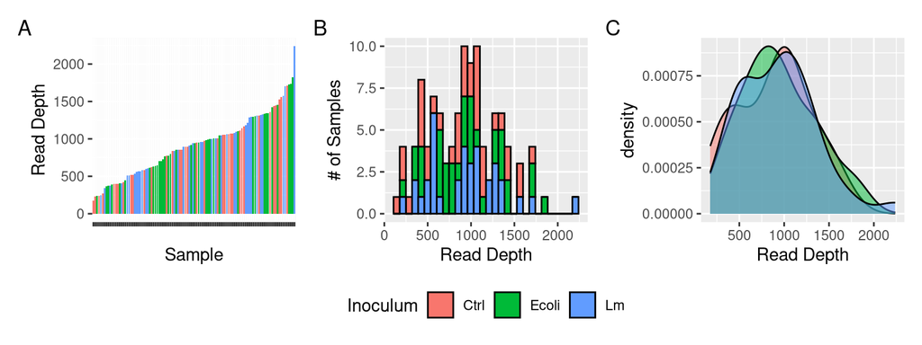

```r
# plot it as a bar plot
numSeq_bar_plot <-
  seqSums_df %>%
  ggplot(aes(x=reorder(names, TotalSeqs), y = TotalSeqs, fill = Inoculum)) +
  geom_bar(stat = "identity") +
  theme(axis.text.x = element_blank()) +
  labs(y = "Read Depth", x = "Sample") +
  theme(legend.position = "none")

# histogram
numSeq_hist_plot <-
  seqSums_df %>%
  ggplot(aes(x= TotalSeqs, fill = Inoculum)) +
  geom_histogram(color = "black") +
  labs(y = "# of Samples", x = "Read Depth") +
  theme(legend.position = "bottom")

# Density plot
numSeq_density_plot <-
  seqSums_df %>%
  ggplot(aes(TotalSeqs, fill = Inoculum)) +
  geom_density(alpha = 0.5) +
  labs(x = "Read Depth") +
  theme(legend.position = "none")

# Put it all together
numSeq_bar_plot + numSeq_hist_plot + numSeq_density_plot +
  plot_annotation(tag_levels = "A")
```

INTERPRETATION #5: What can you conclude about your sequencing depths? What are your sample distributions? Do you have “enough” reads? Are there any samples that should be removed at this step?:

- Panel A shows read depth per sample. Each bar represents the total number of reads (library size) per sample. There is a wide variation in sequencing depth across samples. Some samples have less than 500 reads, while others exceed 2,000 reads. This variation in sequencing depth might influence downstream diversity analyses.
- Panel B shows distribution of read depths. Most samples cluster around 500-1,000 reads. There might be some outliers with very low or very high sequencing depths.
- Panel C shows a density plot of read depth distribution on a continuous scale. It is similar to Panel B and shows a peak around 900-1,000 reads.

The majority of samples fall within the 500–1,500 read range, with a peak around ~900–1,000 reads. There are quite a few samples that have very low read depths (<1,000), which might impact downstream analyses (especially diversity metrics). I don’t think I have enough reads across all samples for the calculation of diversity metrics. I think at this point, I have to remove samples with <1,000 reads. However, this will result in removing half of my samples. Therefore, for now I will keep all my samples. (I also analyzed whether sequencing depth varied in relation to other independent variables in my dataset, such as collection time, season, or brand. My rationale was that if low read depth was consistently associated with a particular group or condition, I might disregard that independent variable for the downstream analyses. However, the read depth doesn’t seem to be associated with the samples collected at different times/seasons/brand).

## Remove samples with few reads

If you find any samples that should obviously be removed at this step, you can follow the code below for your samples. However, if your samples have some but not many reads—like 1000 counts-it is worthwhile to keep those samples in your dataset and remove them later, especially if they are very important!

You can watch this video by [Dr. Pat Schloss](https://riffomonas.org/code_club/2022-04-07-sampling-depth), which talks about how to find the best sampling depth for rarefaction to give you some idea.

```r
# What's the min seq depth?
#min(sample_sums(noChlorosMitosNegPosControls_physeq))

# Remove 20210615-MA-SCB2F
#raw_preprocessed_physeq <-
  #noChlorosMitosNegPosControls_physeq %>%
  #subset_samples(., names != "20210615-MA-SCB2F")

#What's the new min seq depth?
#min(sample_sums(raw_preprocessed_physeq))

# Final check of the sequencing depth for now
# Here, we could remove more samples if we needed to
#seqSums_df %>%
  #dplyr::select(names, TotalSeqs) %>%
  #arrange(TotalSeqs) %>%
  #head(n = 10)
```

# 9. Save Output

## Raw Preprocessed Phyloseq Object

Finally, let’s save our phyloseq object, which we will use for the next step!

```r
# After building phylogenetic tree, I realized there was one sample (SRR17327710) with two copies of ASV0340 which was from Eukaryo Kingdom. Therefore, I'm removing that ASV from my dataset.
noChlorosMitosEuks_physeq <- subset_taxa(noChlorosMitos_physeq, Kingdom != "Eukaryota")
raw_preprocessed_physeq <- noChlorosMitosEuks_physeq
save(raw_preprocessed_physeq, file = "data/03_PreProcessing/raw_preprocessed_physeq.RData")
```

# Final info for Reproducibility

## Check Render Time

```r
# Take the time now that we are at the end of the script
end_time <- Sys.time()
end_time
```

```
## [1] "2025-03-30 12:39:40 EDT"
```

```r
# Echo the elapsed time
elapsed_time <- round((end_time - start_time), 3)
elapsed_time
```

```
## Time difference of 2.706 secs
```